# Homework 1

Liwam Andom & Diletta Abbonato

## Exercise 1

### 1

#### b.

For each of these triplets, repeat $M = 100$ times the one-step testing procedure and *approximate* the probability of error with the proportion of times $($out of $M)$ you get a wrong output.

```r
k = c(5,50,100,500)  # the dimension of the matrix
M  = 100
#here we try to estimate the probabilities of the sample, i.e. U,V,W
p_1 = c()
#loop for each k
for (j in k){
  false=0
  check_mat = F
  while(!check_mat){
    # we randomize the creation of the matrices
    U=matrix(round(runif(j*j, min = 0, max = 1)), nrow = j)#they are the same for each k
    v=matrix(round(runif(j*j, min = 0, max = 1)), nrow = j)
    w=matrix(round(runif(j*j, min = 0, max = 1)), nrow = j)

    if(!isTRUE(all.equal((U%*%v)%%2,w) ) ) { #check if U*V == W and if so, break out of the loop
      check_mat = T
    }
  }
  # loop 100 times
  for(i in 1:M){

    z = c(round(runif(j, min = 0, max = 1)))
    uvz = (U%*%v%*%z)%%2 #correct
    wz = (w%*%z)%%2

    if(isTRUE(all.equal(wz,uvz) ) ){
      false =false+1  # count
    }

  }
  p_1 = c(p_1,false/M) # probabiliy for each k
}
(p_1)
```

```
## [1] 0.04 0.00 0.00 0.00
```

#### c.

Do it again but with $M = 1000$. For speed, check and use the foreach package or any other parallelization scheme.

```r
#import package for parallel execution
library(foreach)
library(doParallel)
registerDoParallel(cores = 4)
p_2 = c()
M = 1000
loop_function = function(j, U, v, w){

  z = c(round(runif(j, min = 0, max = 1)))
  uvz = (U%*%v%*%z)%%2 #correct
  wz = (w%*%z)%%2

  return(isTRUE(all.equal(U%*%v,w)))

}

for(j in k){

  check_mat = F

  while(!check_mat){

    U=matrix(round(runif(j*j, min = 0, max = 1)), nrow = j)#they are the same for each k
    v=matrix(round(runif(j*j, min = 0, max = 1)), nrow = j)
    w=matrix(round(runif(j*j, min = 0, max = 1)), nrow = j)

    if(!isTRUE(all.equal(U%*%v,w))) {
      check_mat = T
    }

  }
  #executing parallelly with foreach
  p_2 = c(p_2, M^(-1) *foreach(i = c(1:M), .combine = sum ) %dopar% loop_function(j,U, v, w) )
}
(p_2)
```

```
## [1] 0 0 0 0
```

Do it again but with $M = 10000$. For speed, check and use the foreach package or any other parallelization scheme.

```r
p_3 = c()
M = 10000
loop_function = function(j, U, v, w){

  z = c(round(runif(j, min = 0, max = 1)))
  uvz = (U%*%v%*%z)%%2 #correct
  wz = (w%*%z)%%2

  return(isTRUE(all.equal(U%*%v,w)))

}

for(j in k){

  check_mat = F

  while(!check_mat){

    U=matrix(round(runif(j*j, min = 0, max = 1)), nrow = j)#they are the same for each k
    v=matrix(round(runif(j*j, min = 0, max = 1)), nrow = j)
    w=matrix(round(runif(j*j, min = 0, max = 1)), nrow = j)

    if(!isTRUE(all.equal(U%*%v,w))) {
      check_mat = T
    }

  }
  p_3 = c(p_3, M^(-1) *foreach(i = c(1:M), .combine = sum ) %dopar% loop_function(j,U, v, w) )
}
(p_3)
```

```
## [1] 0 0 0 0
```

#### d.

Extensively comment the results obtained in terms of speeed $($in $k)$ and error probability, and compare them with their theoretical counterparts highlighted above. Are the theoretical bounds tight or not? Did the parallelization help or not?

The algorithm runs in $O(k^2)$ time because the matrix multiplication is associative, so it can be computed as $U(Vz)$ and $(Wz)$, this requiring only three matrix-vector multiplications for the algorithm. There is only one value for $z_{i}$ that could have caused $(UVz-Wz=0)$. $z_{i}$ element of $z=(z_{1},z_{2},...z_{n})$ so the probability of $(UVz-Wz=0)$ is $\leqslant \frac{1}{2}$

The theoretical bounds are correct, depending on the dimension of the matrix. The bounds get loose as the dimension increases.

The parallelization doesn’t impact the error of probability.

Parallelization with foreach is useful as far as memory is concerned, because it has a better management than the for and while cycle, while for the speed we have not noticed a big difference

### Exercise 2

#### a.

```r
checkVectorMultiplication = function(j, U, v, w){

  z = c(round(runif(j, min = 0, max = 1)))
  uvz = (U%*%v%*%z)%%2 #correct
  wz = (w%*%z)%%2
  return(identical(wz,uvz))

}

p = 100
j = 5

  check_mat = F

while(!check_mat){

  U=matrix(round(runif(j*j, min = 0, max = 1)), nrow = j)#they are the same for each k
  v=matrix(round(runif(j*j, min = 0, max = 1)), nrow = j)
  w=matrix(round(runif(j*j, min = 0, max = 1)), nrow = j)

  if(!(identical(U%*%v,w) ) ){
    check_mat = T
  }
}

falsePosetive <- F
for (i in 1:p){
  while(falsePosetive){
    falsePosetive <- checkVectorMultiplication(j,U,v,w)
  }
  break
}
if(!falsePosetive){
  print('no')
}else{
  print('yes')
}
```

```
## [1] "no"
```

#### b.

Only one step to test $p=1$

$E$ means “identity is correct”"

$E:UV=W$

$B$ means positive test

$P(B|E)= P(UVz=Wz|UV=W)=1$

$P(B|E^{c})=P(UVz=Wz|UV\neq W)\leqslant \frac{1}{2}$

let $P(E)=q$ that represent the prior probability that the identity is correct

$P(E|B)=\frac{P(B|E)*P(E)}{ P(B|E)*P(E)+P(B|E^{c})*P(E^{c})}$ = #bayes

remembr that $q+P(B|E^{c})*(1-q)\leqslant \frac{1}{2}*(1-q)+q=\frac{1}{2}+\frac{q}{2}$ so $P(E|B)\geq\frac{q}{(\frac{1}{2})*(1+q)}=\frac {2q}{1+q}$ and we call $P(E|B)=f(q)$

##### how change E in the light about our asumption

so if $q=0$ $\Rightarrow$ $f(q)=0$ and if $q=1$ $\Rightarrow$ $f(q)=1$

also $f'(q) \geq 0$

#### c.

$B{j}$ : where test-$j$ correct

$P(E|\cap Bj)$= $P(\cap Bj|E)*P(E)/(\cap Bj|E)*P(E)+P(\cap B{j}|E^{c})*P(E^{c})$

$P(B{j}|E)=P(UVz=Wz|UV=W) = 1$

$P(\cap B{j}|E) = \prod P(B{j}|E) = 1$ where $j = 1$ to $r$

$P(\cap B{j}|E^{c})= \prod P(B{j}|E^{c}) \leq \frac {1}{2^p}$

Let $P(E) = q$

$P(E|\cap B{j})=\frac {q}{q+(1-q)*2^{-p}}$ where $r=50$ because $r$ is $p=50$ , we assume that $p=r$

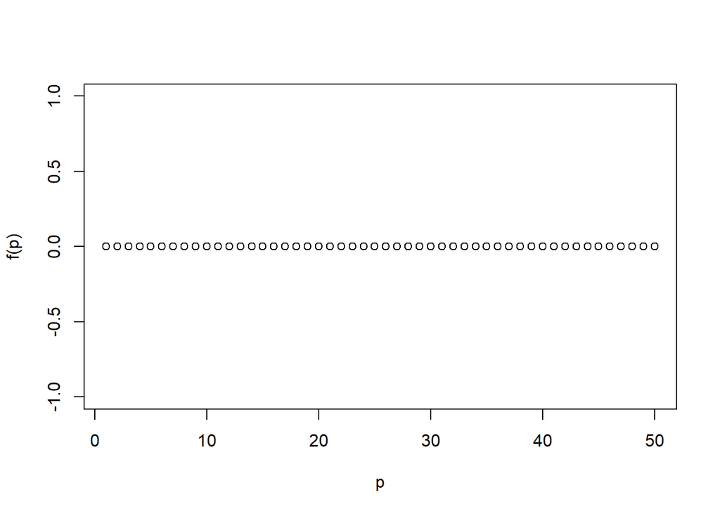

```r
q = round(runif(1,min = 0, max = 1))
plot( (r <- 1:50), ((q/(q+((1-q)*(1/(2^r)))))), xlab = 'p', ylab = 'f(p)')
```

## Exercise 2: Pick one…

## version B

$P(Pi|Pj)$ is the probability of win with door $i$ if the door $j$ is open. Where $(i,j)=1,2,3$ and $i\neq j$

$P(Pi|Pj)=\frac{P(Pj|Pi)*P(Pi)}{P(Pj|Pi)*P(Pi)+P(Pj|Pi^{c})*P(Pi^{c})}$

$P(Pj|Pi)=1$

$P(Pi)=\frac{1}{2}$

$P(Pj|Pi^{c})=1$

$P(Pi^{c})=\frac{1}{2}$

so $P(Pi|Pj)=\frac{1}{2}$

The difference from the original Monty Hall paradox is that changing the chosen door will not affect the probability of victory, which is, therefore, $\frac{1}{2}$

```r
win = 0
lose = 0
for(i in 1:100){
  options = c(1,2,3)

  choice1 = round(runif(1, min=1, max=3)) #choice of the contestant door

  #earthquake opens one door, boom badash boooooooooooooooooom bom
  earthquake=sample(size=1,options[-choice1])

  #the door where the car is
  car = sample(size=1,options[-earthquake])

  if(choice1 == car){
    win = win + 1
  }else{
    lose = lose + 1
  }
}

(win/100) #CAPPUCCINO E CORNETTO PLS
```

```
## [1] 0.5
```

### We collaborated with:

#### Amr Elshibiny

#### Matteo Cavalletti

#### Edoardo Cantagallo

#### Melis Kaymaz

#### Musie Meressa Berhe